# Presentación: Salud y Felicidad percibida en Europa

01/09/2025

## 1. Introducción

Este informe forma parte del proyecto de Ciencia de Datos reproducible del Máster en Behavioral Data Science (IL3 - UB).

### Objetivo principal:

#### Analizar algunos de los factores sociodemográficos y contextuales que influyen en la felicidad y la salud autopercibidas en Europa, con el fin de identificar patrones y relaciones relevantes.

### Objetivos específicos:

- **Observar diferencias internacionales:** Comparar la distribución geográfica de la salud y la felicidad autopercibida en Europa.
- **Explorar relaciones entre variables:** Explorar la relación entre salud y felicidad autopercibida.
- **Analizar la dimensión etaria:** Examinar cómo se relaciona la edad con los niveles de felicidad y de salud reportados.
- **Estudiar la dimensión de género:** Identificar si existen diferencias de género en los niveles de felicidad percibida y de salud.
- **Considerar la condición migratoria:** Determinar si la población nacida fuera del país reporta distintos niveles de felicidad y de salud respecto a la población nativa.

## 2. Datos y metodología

Los análisis se basan en los datos de la encuesta European Social Survey “ESS11 edition 3.0”, descargados el 20/08/2025.

Se han seleccionado las variables de:

- felicidad (`happy`)
- salud (`health`)
- edad (`agea`)
- género (`gndr`)
- lugar de nacimiento (`brncntr`).

Los análisis combinan tablas resumen, pruebas estadísticas y gráficos descriptivos.

## 3. Resultados principales

### 3.1. Relación entre salud autopercibida y felicidad

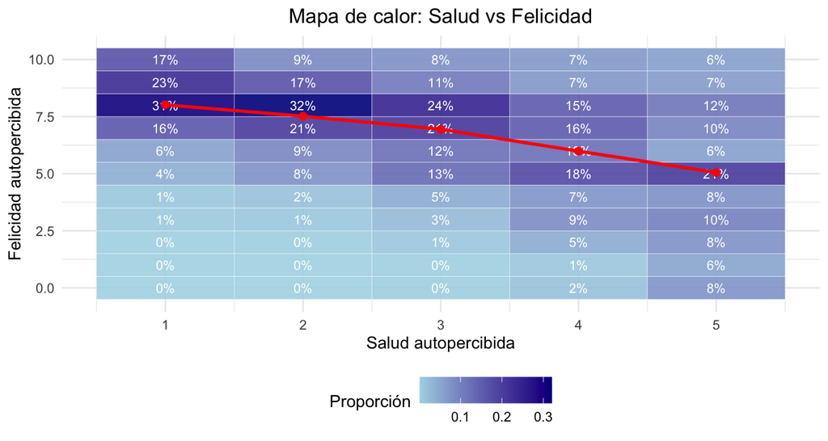

Relación monótona inversa y estadísticamente significativa entre salud y felicidad percibidas.

### 3.1. Relación entre salud autopercibida y felicidad

Test de correlación de Spearman entre salud y felicidad

|  | p_value | rho |
| --- | --- | --- |
| rho | 0 | -0.282 |

La mayoría de las respuestas se concentran en los valores de salud medio-bajos y de felicidad medio-altos.

### 3.2. Interacción con factores sociodemográficos

#### Edad

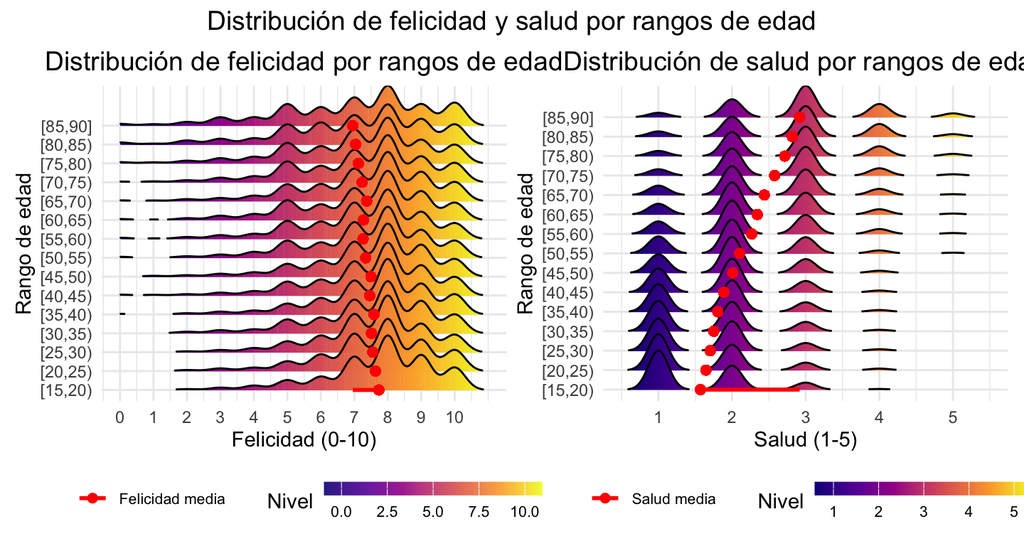

Se observa una tendencia a puntuar más bajo en felicidad pero más alto en salud percibida cuanto mayor es el rango de edad, lo que sigue el patrón inverso entre ambas variables.

#### Género

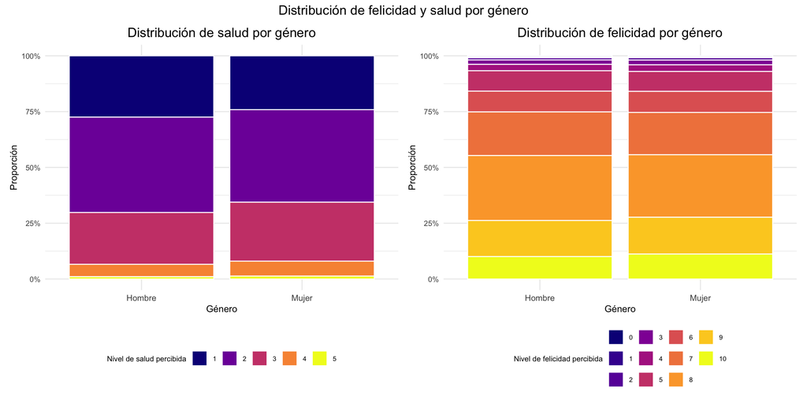

Aunque existen ligeras diferencias en los niveles altos de felicidad y salud entre hombres y mujeres, la distribución general es bastante similar entre ambos géneros.

#### Condición migratoria

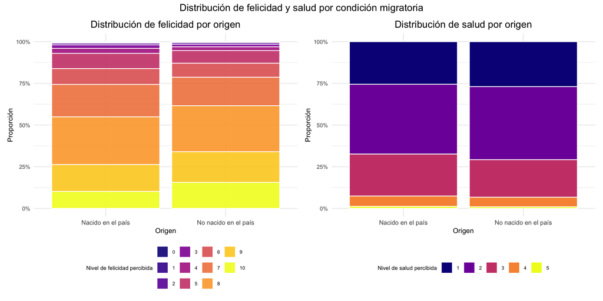

La población no nacida en el país tiende a reportar niveles más altos de felicidad, mientras que la población nativa puntúa más alto en salud percibida.